# Assignment 1

ChengYue Zhang

# Download Packages

- R (R Core Team (2022))
- BiocManager (Morgan (2021))
- [GEOmetadb](https://bioconductor.org/packages/release/bioc/html/GEOmetadb.html) (McCarthy, Y, and Smyth (2012))
- [edgeR](https://bioconductor.org/packages/release/bioc/html/edgeR.html) (Robinson, DJ, and Smyth (2010), McCarthy, Y, and Smyth (2012), Chen, Lun, and Smyth (2016))
- [limma](https://bioconductor.org/packages/release/bioc/html/limma.html) (Ritchie et al. (2015))
- [biomaRt](https://bioconductor.org/packages/release/bioc/html/biomaRt.html) (Durinck et al. (2009), Durinck et al. (2005))
- [GEOquery](https://bioconductor.org/packages/release/bioc/html/GEOquery.html) (Davis and Meltzer (2007))
- [Biobase & BioGenerics](https://bioconductor.org/packages/release/bioc/html/Biobase.html) (Huber et al. (2015))

```r
if (!requireNamespace("BiocManager", quietly = TRUE)){
  install.packages("BiocManager")}

if (!requireNamespace("GEOmetadb", quietly = TRUE)){
  BiocManager::install("GEOmetadb")}

if (!requireNamespace("ggplot2", quietly = TRUE)){
  install.packages("ggplot2")}

if (!requireNamespace("knitr", quietly = TRUE)){
  install.packages("knitr")}

if (!requireNamespace("RSQLite", quietly = TRUE)){
  install.packages("RSQLite")}

if (!requireNamespace("edgeR", quietly = TRUE)){
  BiocManager::install("edgeR")}

if (!requireNamespace("limma", quietly = TRUE)){
  BiocManager::install("limma")}

if (!requireNamespace("biomaRt", quietly = TRUE)){
  BiocManager::install("biomaRt")}

if (!requireNamespace("GEOquery", quietly = TRUE)){
  BiocManager::install("GEOquery")}

if (!requireNamespace("Biobase", quietly = TRUE)){
  BiocManager::install("Biobase")}


if (!requireNamespace("odbc", quietly = TRUE)){
  install.packages("odbc")}

if (!requireNamespace("dplyr", quietly = TRUE)){
  install.packages("dplyr")}

if (!requireNamespace("DBI", quietly = TRUE)){
  install.packages("DBI")}

if (!requireNamespace("kableExtra", quietly = TRUE)){
  install.packages("kableExtra")}
```

Load packages

```r
library("GEOmetadb")
library("ggplot2")
library("knitr")
library("RSQLite")
library("edgeR")
library("limma")
library("biomaRt")
library("GEOquery")
library("Biobase")
library("odbc")
library("dplyr")
library("DBI")
library("kableExtra")
```

# Select an Expression Data Set

## 1. Download the data

Get the GEO description of my dataset GSE162515

```r
gse <- getGEO("GSE162515",GSEMatrix=FALSE)
kable(data.frame(head(Meta(gse))), format = "html")
```

| contact_address | contact_city | contact_country | contact_institute | contact_name | contact_state |
| --- | --- | --- | --- | --- | --- |
| 3165 Porter Drive | Palo Alto | USA | Stanford University | Akshay,,Sanghi | California |

Information about platform

```r
current_gpl <- names(GPLList(gse))[1]
current_gpl_info <- Meta(getGEO(current_gpl))

current_gpl_info$title
```

```
[1] "Illumina NovaSeq 6000 (Homo sapiens)"
```

```r
current_gpl_info$last_update_date
```

```
[1] "Nov 05 2018"
```

```r
current_gpl_info$organism
```

```
[1] "Homo sapiens"
```

Get the expression data

```r
sfiles <- getGEOSuppFiles('GSE162515')
```

There are four supplement files. Here, I will choose [4] which is the RNAseq raw counts file.

```r
fnames <- rownames(sfiles)
ntm_exp <- read.delim(fnames[4],header=TRUE,
                check.names = FALSE)
fnames
```

```
[1] "/Users/antioxidant233/St.George/2023Winter/BCB420/ChengYue_Zhang/A1/GSE162515/GSE162515_ATACseq_logCounts.txt.gz"
[2] "/Users/antioxidant233/St.George/2023Winter/BCB420/ChengYue_Zhang/A1/GSE162515/GSE162515_NonPromoter_GeneLinks.txt.gz"
[3] "/Users/antioxidant233/St.George/2023Winter/BCB420/ChengYue_Zhang/A1/GSE162515/GSE162515_Promoter_Regions.txt.gz"
[4] "/Users/antioxidant233/St.George/2023Winter/BCB420/ChengYue_Zhang/A1/GSE162515/GSE162515_RNAseq_rawCounts.txt.gz"
```

Information about expression data (i.e. gene names, chromosome, start/end position, sequence length) are from column 88 to 92 in the table. Move these to the first column for better visualization and processing.

```r
expInfos <- ntm_exp[, seq(88, 92)]

ntm_exp <- cbind(expInfos, ntm_exp[, seq(-88, -92)])
```

Check the table

```r
kable(ntm_exp[1:15,1:15], format = "html")
```

| Gene | Chr | Gene_start | Gene_end | Length | F001 | F002 | F003 | F004 | F005 | F007 | F009 | F010 | F014 | F017 |
| --- | --- | --- | --- | --- | --- | --- | --- | --- | --- | --- | --- | --- | --- | --- |
| A1BG | chr19 | 58345278 | 58353492 | 8214 | 2 | 3 | 1 | 0 | 0 | 2 | 3 | 9 | 3 | 0 |
| A1BG-AS1 | chr19 | 58347818 | 58355455 | 7637 | 288 | 116 | 186 | 157 | 32 | 155 | 61 | 105 | 60 | 231 |
| A2M | chr12 | 9067764 | 9116229 | 48465 | 18522 | 19869 | 12240 | 14859 | 4560 | 20017 | 13014 | 27452 | 5887 | 20372 |
| A2M-AS1 | chr12 | 9065263 | 9068689 | 3426 | 11 | 57 | 24 | 18 | 25 | 10 | 13 | 63 | 61 | 11 |
| A2ML1 | chr12 | 8822721 | 8887001 | 64280 | 0 | 0 | 3 | 0 | 1 | 0 | 0 | 16 | 5 | 2 |
| A2MP1 | chr12 | 9228633 | 9275817 | 47184 | 2 | 7 | 2 | 4 | 0 | 2 | 0 | 0 | 0 | 0 |
| A3GALT2 | chr1 | 33306866 | 33321098 | 14232 | 0 | 0 | 0 | 0 | 1 | 0 | 0 | 0 | 1 | 4 |
| A4GALT | chr22 | 42692221 | 42721298 | 29077 | 182 | 350 | 274 | 295 | 81 | 176 | 193 | 377 | 182 | 336 |
| AAAS | chr12 | 53307556 | 53324864 | 17308 | 855 | 757 | 483 | 915 | 214 | 559 | 590 | 1025 | 269 | 557 |
| AACS | chr12 | 125065534 | 125143333 | 77799 | 657 | 630 | 339 | 434 | 221 | 508 | 578 | 993 | 359 | 426 |
| AADAC | chr3 | 151814173 | 151828488 | 14315 | 0 | 3 | 1 | 0 | 0 | 0 | 0 | 0 | 2 | 0 |
| AADACL2-AS1 | chr3 | 151751543 | 151928175 | 176632 | 0 | 1 | 0 | 0 | 0 | 1 | 0 | 1 | 2 | 1 |
| AADACP1 | chr3 | 151770528 | 151784894 | 14366 | 5 | 28 | 2 | 5 | 1 | 1 | 0 | 41 | 161 | 36 |
| AADAT | chr4 | 170060322 | 170091699 | 31377 | 109 | 71 | 27 | 107 | 36 | 29 | 43 | 88 | 69 | 82 |
| AAGAB | chr15 | 67200767 | 67255195 | 54428 | 1657 | 1368 | 730 | 2044 | 842 | 1370 | 1222 | 1736 | 1863 | 1062 |

## 2. Assess data quality

How many genes do I have measurements for?

```r
dim(ntm_exp)
```

```
[1] 28883    92
```

Are any of genes duplicated? and Why?

```r
summarized_gene_counts <- sort(table(ntm_exp$Gene),
                               decreasing = TRUE)
```

Only output those with frequency greater than 1

```r
kable(summarized_gene_counts[which(summarized_gene_counts>1)[1:10]], format = 'html')
```

| Var1 | Freq |
| --- | --- |
| ABCF2 | 2 |
| AHRR | 2 |
| ARMCX5-GPRASP2 | 2 |
| C2orf27A | 2 |
| CCDC39 | 2 |
| DUXAP8 | 2 |
| GGT1 | 2 |
| GOLGA8M | 2 |
| HSPA14 | 2 |
| ITFG2-AS1 | 2 |

So yes, there are duplicated genes, but not very significant. The highest frequency of duplicate is only 2. These might be the PCR duplicates that result from sequencing two or more copies of the exact same cDNA fragment. I do not neet to filter them out.

```r
colnames(ntm_exp)[1:15]
```

```
 [1] "Gene"       "Chr"        "Gene_start" "Gene_end"   "Length"     "F001"       "F002"       "F003"       "F004"       "F005"       "F007"
[12] "F009"       "F010"       "F014"       "F017"
```

### Use the GSE series matrix to make the column names informative

Obtain the series matrix file through GEOquery.

```r
gseFile <- getGEO('GSE162515',GSEMatrix=TRUE)
gseInfo <- pData(phenoData(gseFile[[1]]))
```

Filter out the samples that are not RNA-seq.

```r
rnaSeq <- gseInfo[grepl("RNA", gseInfo$title), c(1, 6, 8)]
rnaSeq[1:10,]
```

|  | title | type | source_name_ch1 |
| --- | --- | --- | --- |
| GSM4953494 | RNA-Seq F001-C1-T1 | SRA | Thyroid tumor |
| GSM4953495 | RNA-Seq F002-C1-N1 | SRA | Normal thyroid |
| GSM4953496 | RNA-Seq F003-C1-M1 | SRA | Cervical LymphNode Metastases |
| GSM4953497 | RNA-Seq F004-C2-T1 | SRA | Thyroid tumor |
| GSM4953498 | RNA-Seq F005-C2-N1 | SRA | Normal thyroid |
| GSM4953499 | RNA-Seq F007-C3-T1 | SRA | Thyroid tumor |
| GSM4953500 | RNA-Seq F009-C4-T1 | SRA | Thyroid tumor |
| GSM4953501 | RNA-Seq F010-C4-N1 | SRA | Normal thyroid |
| GSM4953502 | RNA-Seq F014-C5-N1 | SRA | Normal thyroid |
| GSM4953503 | RNA-Seq F017-C7-T1 | SRA | Thyroid tumor |

Process sample names

```r
samples <- lapply(rnaSeq$title, FUN=function(x){unlist(strsplit(x,
                        split = " "))[2]})
sample_types <- substr(samples,1,nchar(samples)-1)
newColNames <- c(colnames(ntm_exp)[1:5], sample_types)
colnames(ntm_exp) <- newColNames
```

**Group the data**

There are three groups of samples, where “T” indicates “Thyroid tumor”, “N” indicates “Normal thyroid, and”M” indicates “Cervical LymphNode Metastases”.

```r
#get the 2 and third token from the column names
samples <- data.frame(lapply(colnames(ntm_exp)[6:92], FUN=function(x){unlist(strsplit(x,
                        split = "\\-"))[c(2,3)]}))
colnames(samples) <- colnames(ntm_exp)[6:92]
rownames(samples) <- c("individual","tissue_type")
samples <- data.frame(t(samples))
```

From the paper (Sanghi, Gruber, and Metwally (2021)), the authors indicates that there are 27 “N” type samples, 30 “T” type samples and 30 “M” type samples. Check whether I have obtained all of them.

```r
sum(grepl("N", samples$tissue_type))
```

```
[1] 27
```

```r
# [1] 27
sum(grepl("T", samples$tissue_type))
```

```
[1] 30
```

```r
# [1] 30
sum(grepl("M", samples$tissue_type))
```

```
[1] 30
```

```r
# [1] 30
```

# Filter out low counts

```r
#translate out counts into counts per million using
#the edgeR package function cpm
cpms <- edgeR::cpm(ntm_exp[,6:92])
rownames(cpms) <- ntm_exp$Gene
# get rid of low counts
keep <- rowSums(cpms >1) >=3
ntm_exp_filtered <- ntm_exp[keep,]
```

**What does that do to the dataset?**

The size of our dataset gets smaller.

```r
dim(ntm_exp)
```

```
[1] 28883    92
```

```r
dim(ntm_exp_filtered)
```

```
[1] 19756    92
```

**What does that do to the duplicates?**

The duplicates do not change. The highest frequency of duplicate is still 2.

```r
summarized_gene_counts_filtered <- sort(table(ntm_exp$Gene),
                               decreasing = TRUE)

kable(summarized_gene_counts_filtered[
  which(summarized_gene_counts_filtered>1)[1:10]],
  format="html")
```

| Var1 | Freq |
| --- | --- |
| ABCF2 | 2 |
| AHRR | 2 |
| ARMCX5-GPRASP2 | 2 |
| C2orf27A | 2 |
| CCDC39 | 2 |
| DUXAP8 | 2 |
| GGT1 | 2 |
| GOLGA8M | 2 |
| HSPA14 | 2 |
| ITFG2-AS1 | 2 |

# Normalization

## Distribution of our data

### Boxplot

The following is the box plot of the original count data, before filtering out any low counts. We can see that there is some fluctuation in the medians, and the overall median is close to 0, indicating the existence of low-expressed or non-expressed genes.

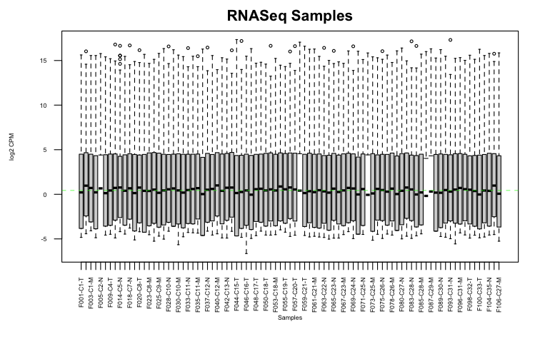

```r
data1plot <- log2(cpm(ntm_exp[,6:92]))
boxplot(data1plot, xlab = "Samples", ylab = "log2 CPM",
        las = 2, cex = 0.5, cex.lab = 0.5,
        cex.axis = 0.5, main = "RNASeq Samples")
#draw the median on each box plot
abline(h = median(apply(data1plot, 2, median)),
       col = "green", lwd = 0.6, lty = "dashed")
```

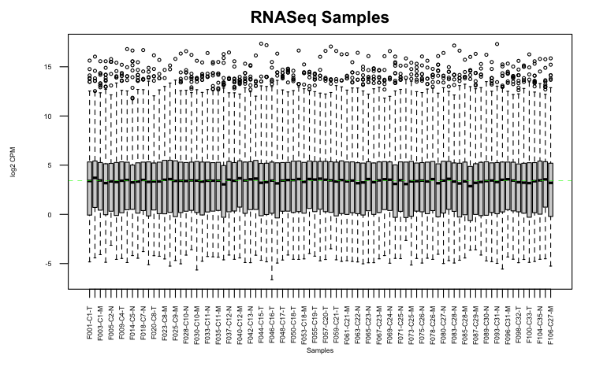

```r
data2plot <- log2(cpm(ntm_exp_filtered[,6:92]))
boxplot(data2plot, xlab = "Samples", ylab = "log2 CPM",
        las = 2, cex = 0.5, cex.lab = 0.5,
        cex.axis = 0.5, main = "RNASeq Samples")
#draw the median on each box plot
abline(h = median(apply(data2plot, 2, median)),
       col = "green", lwd = 0.6, lty = "dashed")
```

### Density plot

Density plot of the filtered expression dataset before normalization. We can see that the counts are already on a comparable scale, and as stated previously, the normalization may not have a significant impact on the data.

```r
counts_density <- apply(log2(edgeR::cpm(ntm_exp_filtered[,6:92])),
                        2, density)
  #calculate the limits across all the samples
    xlim <- 0; ylim <- 0
    for (i in 1:length(counts_density)) {
      xlim <- range(c(xlim, counts_density[[i]]$x));
      ylim <- range(c(ylim, counts_density[[i]]$y))
    }
    cols <- rainbow(length(counts_density))
    ltys <- rep(1, length(counts_density))
    #plot the first density plot to initialize the plot
    plot(counts_density[[1]], xlim=xlim, ylim=ylim, type="n",
         ylab="Smoothing density of log2-CPM",
         main="Density plot", cex.lab = 0.7)
    #plot each line
    for (i in 1:length(counts_density))
      lines(counts_density[[i]], col=cols[i], lty=ltys[i])
```

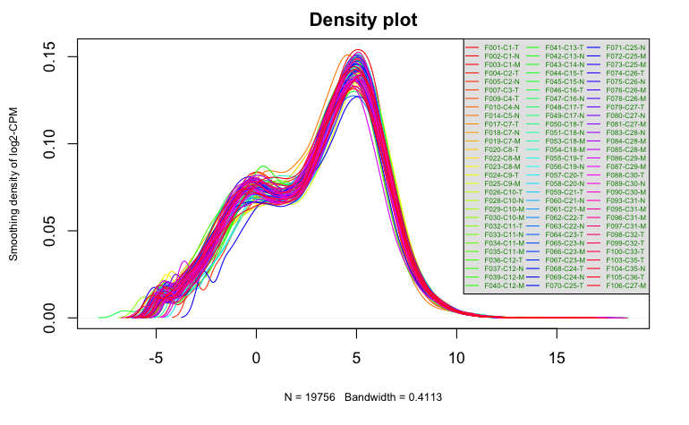

```r
    #create legend
    legend("topright", colnames(data2plot),
           col=cols, lty=ltys, cex=0.45,
           border ="blue",  text.col = "green4",
           merge = TRUE, bg = "gray90", ncol = 3)
```

## MA plot comparing the C1-T1 and C1-N1 sample in data set

We can see that most the genes are clustered, but there are some extremes that are spread out. We aim to get rid of these extreme values from our data.

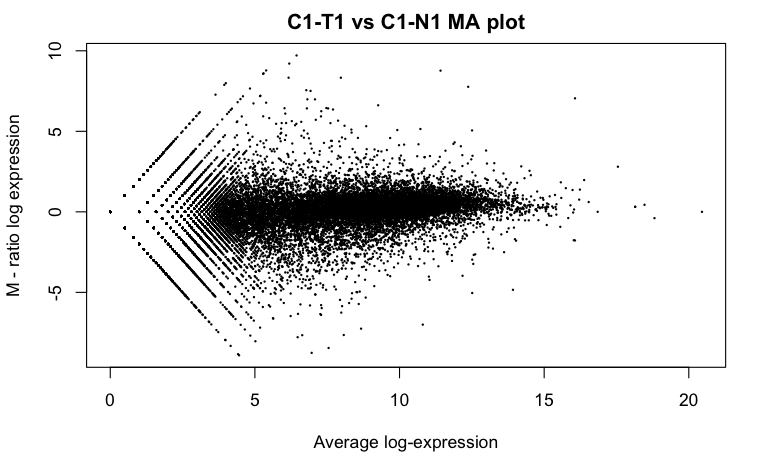

```r
limma::plotMA(log2(ntm_exp[,c(6,7)]), ylab="M - ratio log expression",
       main="C1-T1 vs C1-N1 MA plot")
```

## Applying TMM

Create an edgeR container for RNASeq count data

```r
celltypes <-colnames(ntm_exp)[6:92]
filtered_data_matrix <- as.matrix(ntm_exp_filtered[, 6:92])
rownames(filtered_data_matrix) <- ntm_exp_filtered$Gene
d <- edgeR::DGEList(counts = filtered_data_matrix, group = samples$tissue_type)
```

Calculate normalization factor

```r
d <- calcNormFactors(d)
```

Get the normalized data

```r
#get the normalized data
normalized_counts <- cpm(d)
```

### Boxplot after normalization

The difference between the boxplot before and after normalization is too minimal to be seen, as expected.

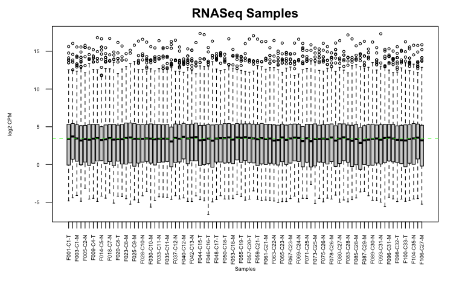

```r
data3plot <- log2(cpm(normalized_counts[,1:87]))
boxplot(data3plot, xlab = "Samples", ylab = "log2 CPM",
        las = 2, cex = 0.5, cex.lab = 0.5,
        cex.axis = 0.5, main = "RNASeq Samples")
#draw the median on each box plot
abline(h = median(apply(data3plot, 2, median)),
       col = "green", lwd = 0.6, lty = "dashed")
```

### Density plot after normalization.

There is no difference in the density plot before and after normalization, or the difference is too minimal to be taken into consideration.

```r
normalized_counts_density <- apply(log2(edgeR::cpm(normalized_counts[,1:87])),
                        2, density)
  #calculate the limits across all the samples
    xlim <- 0; ylim <- 0
    for (i in 1:length(normalized_counts_density)) {
      xlim <- range(c(xlim, normalized_counts_density[[i]]$x));
      ylim <- range(c(ylim, normalized_counts_density[[i]]$y))
    }
    cols <- rainbow(length(normalized_counts_density))
    ltys <- rep(1, length(normalized_counts_density))
    #plot the density plot
    plot(normalized_counts_density[[1]], xlim=xlim, ylim=ylim, type="n",
         ylab="Smoothing density of log2-CPM",
         main="", cex.lab = 0.7)
    #plot each line
    for (i in 1:length(normalized_counts_density))
      lines(normalized_counts_density[[i]], col=cols[i], lty=ltys[i])
```

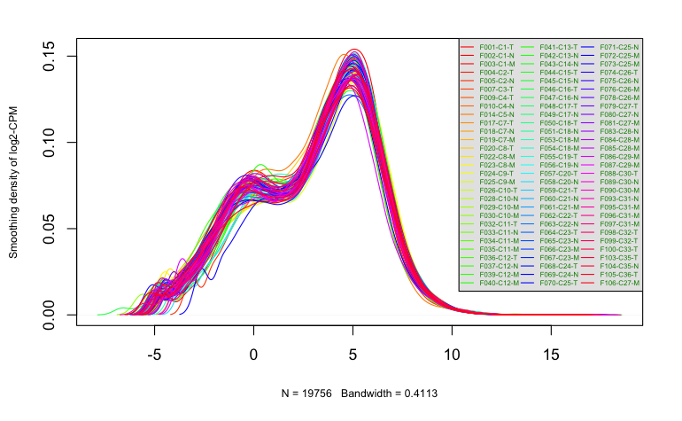

```r
    #create legend
    legend("topright", colnames(data3plot),
           col=cols, lty=ltys, cex=0.45,
           border ="blue",  text.col = "green4",
           merge = TRUE, bg = "gray90", ncol = 3)
```

## MA plot comparing the C1-T1 and C1-N1 sample after normalization

There is no visible difference in the MA plot before and after normalization. This indicates that the dataset was already at a high quality, also as shown in the box plot and the density plot above.

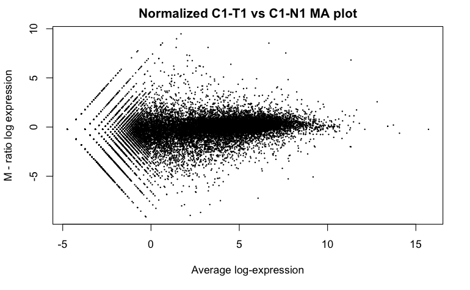

```r
limma::plotMA(log2(normalized_counts[,c(1,2)]), ylab="M - ratio log expression",
       main="Normalized C1-T1 vs C1-N1 MA plot")
```

Inspect the sample separation using a multidimensional scaling plot or MDS plot post normalization.

- Blue: Normal
- Dark green: Mets
- Black: Tumor

From the plot, we can see that the overall separation between each test condition group (T and M) to normal group is good, indicating a good dataset quality.

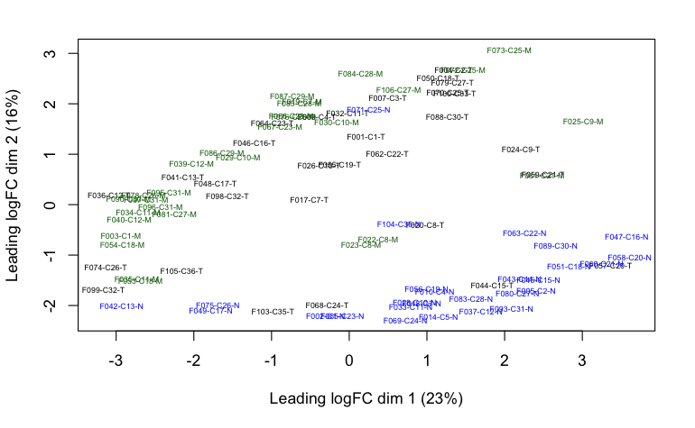

```r
plotMDS(d, cex = 0.5, labels = rownames(samples),
  col = c("darkgreen", "blue")[factor(samples$tissue_type)])
```

# Dispersion

```r
model_design <- model.matrix(~samples$individual
                             + samples$tissue_type+0)
d <- edgeR::estimateDisp(d, model_design)
```

Graphing the dispersion-squared BCV.

We can see that genes with low counts have a higher variation, whereas genes with higher counts have a lower variation towards the expected trend. For our dataset, the trend of the count data falls around the common dispersion line in a BCV plot, indicating that the variance of the data is relatively consistent with the expected trend.

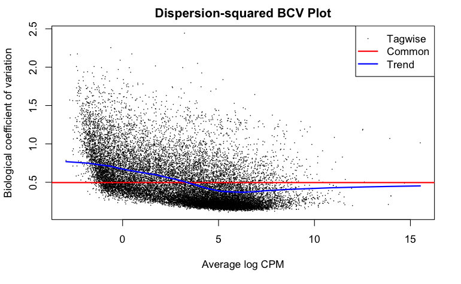

```r
plotBCV(d,col.tagwise = "black",col.common = "red", main = "Dispersion-squared BCV Plot")
```

# Identifier mapping

Get all availale marts

```r
listMarts()
```

| biomart | version |
| --- | --- |
| ENSEMBL_MART_ENSEMBL | Ensembl Genes 109 |
| ENSEMBL_MART_MOUSE | Mouse strains 109 |
| ENSEMBL_MART_SNP | Ensembl Variation 109 |
| ENSEMBL_MART_FUNCGEN | Ensembl Regulation 109 |

```r
#If different version is needed
listEnsemblArchives()[1:10,]
```

|  | name | date | url | version | current_release |
| --- | --- | --- | --- | --- | --- |
| 1 | Ensembl GRCh37 | Feb 2014 | https://grch37.ensembl.org | GRCh37 |  |
| 2 | Ensembl 109 | Feb 2023 | https://feb2023.archive.ensembl.org | 109 | * |
| 3 | Ensembl 108 | Oct 2022 | https://oct2022.archive.ensembl.org | 108 |  |
| 4 | Ensembl 107 | Jul 2022 | https://jul2022.archive.ensembl.org | 107 |  |
| 5 | Ensembl 106 | Apr 2022 | https://apr2022.archive.ensembl.org | 106 |  |
| 6 | Ensembl 105 | Dec 2021 | https://dec2021.archive.ensembl.org | 105 |  |
| 7 | Ensembl 104 | May 2021 | https://may2021.archive.ensembl.org | 104 |  |
| 8 | Ensembl 103 | Feb 2021 | https://feb2021.archive.ensembl.org | 103 |  |
| 9 | Ensembl 102 | Nov 2020 | https://nov2020.archive.ensembl.org | 102 |  |
| 10 | Ensembl 101 | Aug 2020 | https://aug2020.archive.ensembl.org | 101 |  |

Connect to the desired mart

```r
ensembl <- useMart("ensembl")
```

Get the set of datasets available

```r
datasets <- listDatasets(ensembl)
knitr::kable(head(datasets),format = "html")
```

| dataset | description | version |
| --- | --- | --- |
| abrachyrhynchus_gene_ensembl | Pink-footed goose genes (ASM259213v1) | ASM259213v1 |
| acalliptera_gene_ensembl | Eastern happy genes (fAstCal1.2) | fAstCal1.2 |
| acarolinensis_gene_ensembl | Green anole genes (AnoCar2.0v2) | AnoCar2.0v2 |
| acchrysaetos_gene_ensembl | Golden eagle genes (bAquChr1.2) | bAquChr1.2 |
| acitrinellus_gene_ensembl | Midas cichlid genes (Midas_v5) | Midas_v5 |
| amelanoleuca_gene_ensembl | Giant panda genes (ASM200744v2) | ASM200744v2 |

Limit to the human datasets available

```r
knitr::kable(head(datasets[grep(datasets$dataset,
                  pattern = "sapiens"),]),format = "html")
```

|  | dataset | description | version |
| --- | --- | --- | --- |
| 79 | hsapiens_gene_ensembl | Human genes (GRCh38.p13) | GRCh38.p13 |

```r
ensembl <- useDataset("hsapiens_gene_ensembl",mart=ensembl)
```

## Building a Biomart Query

How many filters are there?

```r
dim(listFilters(ensembl))
```

```
[1] 435   2
```

What do those filters look like?

```r
knitr::kable(listFilters(ensembl)[1:10,1:2], type="html")
```

| name | description |
| --- | --- |
| chromosome_name | Chromosome/scaffold name |
| start | Start |
| end | End |
| band_start | Band Start |
| band_end | Band End |
| marker_start | Marker Start |
| marker_end | Marker End |
| encode_region | Encode region |
| strand | Strand |
| chromosomal_region | e.g. 1:100:10000:-1, 1:100000:200000:1 |

```r
biomart_human_filters <- listFilters(ensembl)
```

## Attributes

This dataset stores the genes in various ways, including HGNC symbols, GenBank IDs, and NCBI accessions. To make sure I obtain as many identifiers as possible, I will convert each type separately to HGNC symbols(except for the ones already represented as HGNC symbols).

Use the function **searchAttributes** to find the attributes I am looking for

```r
kable(searchAttributes(mart = ensembl, 'hgnc') , format="html") %>%
  row_spec(2, background = "yellow")
```

|  | name | description | page |
| --- | --- | --- | --- |
| 62 | hgnc_id | HGNC ID | feature_page |
| 63 | hgnc_symbol | HGNC symbol | feature_page |
| 93 | hgnc_trans_name | Transcript name ID | feature_page |

Use the homo sapiens database from Ensembl:

```r
httr::set_config(httr::config(ssl_verifypeer = FALSE))
ensembl <- biomaRt::useMart("ensembl", dataset="hsapiens_gene_ensembl")
```

Obtain the genes that are already mapped to HGNC symbols in the original dataset:

```r
conversion_stash <- "gene_conversion.rds"
if (file.exists(conversion_stash)) {
  gene_conversion <- readRDS(conversion_stash)
} else {
  gene_conversion <- biomaRt::getBM(attributes = "hgnc_symbol",
                                  filters = "hgnc_symbol",
                                  values = ntm_exp_filtered$Gene,
                                  mart = ensembl)
  saveRDS(gene_conversion, conversion_stash)
}
```

Obtain the dataset with genes that are not represented by HGNC symbols

```r
not_hgnc <- ntm_exp_filtered[-(which(rownames(normalized_counts) %in% gene_conversion$hgnc_symbol)), ]
```

## 1. Convert Entrez accessions to HGNC symbols

```r
kable(searchAttributes(mart = ensembl, 'entrez') , format="html")
```

|  | name | description | page |
| --- | --- | --- | --- |
| 58 | entrezgene_trans_name | EntrezGene transcript name ID | feature_page |
| 77 | entrezgene_description | NCBI gene (formerly Entrezgene) description | feature_page |
| 78 | entrezgene_accession | NCBI gene (formerly Entrezgene) accession | feature_page |
| 79 | entrezgene_id | NCBI gene (formerly Entrezgene) ID | feature_page |

```r
entrez_conversion <- getBM(attributes = c("entrezgene_accession","hgnc_symbol"),
                    filters = "entrezgene_accession",
                    values = not_hgnc$Gene,
                    mart = ensembl)
# Change the row names of the genes matched to HUGO symbols
rownames(normalized_counts)[which(rownames(normalized_counts) %in% entrez_conversion$entrezgene_accession)] <- entrez_conversion$hgnc_symbol
```

## 2. Convert GenBank IDs to HGNC symbols

According to [HGNC website of BioMart](https://www.genenames.org/help/biomart/) help page, the attribute used to map GenBank IDs to HGNC symbols is named as **INSDC**.

```r
genbank <- not_hgnc[-(which(not_hgnc$Gene %in% entrez_conversion$entrezgene_accession)), ]
knitr::kable(biomart_human_filters[
  grep(biomart_human_filters$description,pattern="INSDC"),],
      format="html")
```

|  | name | description |
| --- | --- | --- |
| 24 | with_protein_id | With INSDC protein ID ID(s) |
| 81 | protein_id | INSDC protein ID(s) [e.g. AAA02489] |

** Can some of our GenBank accession numbers map to it**?

By limiting the filter to homo sapiens, I obtained no results. Since these GenBank accession numbers are not able to map to any alternative names, I have to ignore them from our dataset.

```r
dim(getBM(attributes = c("protein_id","hgnc_symbol"),
                    filters = "protein_id",
                    values = genbank$Gene,
                    mart = ensembl))
```

```
[1] 0 2
```

## 3. Get rid of the genes (if any) that are mapped to none of the conversion datasets above.

```r
mapped_index <- which((rownames(normalized_counts) %in% entrez_conversion$hgnc_symbol) |
                    (rownames(normalized_counts) %in% gene_conversion$hgnc_symbol))


normalized_counts_annot <- normalized_counts[mapped_index, ]
```

How many genes left?

```r
dim(normalized_counts_annot)
```

```
[1] 17368    87
```

**Are there any duplicates?**

Yes, there are 23 duplicated identifiers.

```r
dup_id <- which(duplicated(rownames(normalized_counts_annot)) == TRUE)
length(dup_id)
```

```
[1] 23
```

These are the duplicated identifiers.

```r
rownames(normalized_counts_annot[dup_id, ])
```

```
 [1] "ABCF2"          "AHRR"           "ARMCX5-GPRASP2" "C2orf27A"       "CCDC39"         "DUXAP8"         "ANKRD18A"       "GGT1"
 [9] "GOLGA8M"        "HSPA14"         "ITFG2-AS1"      "LINC01238"      "MATR3"          "PDE11A"         "PINX1"          "POLR2J3"
[17] "POLR2J4"        "RMRP"           "SNORA50A"       "SOD2"           "TBCE"           "TMSB15B"        "ZNF883"
```

**What are they?**

Most of them are non-coding RNAs and pseudogenes, so we can just remove them.

```r
gene_description <- getBM(attributes = c("description","hgnc_symbol"),
                    filters = "hgnc_symbol",
                    values = rownames(normalized_counts_annot[dup_id, ]),
                    mart = ensembl)
```

Get rid of the duplicated rows

```r
normalized_counts_final <- normalized_counts_annot[-dup_id,]
```

The final dataset:

```r
kable(head(normalized_counts_final), format = "html")
```

|  | F001-C1-T | F002-C1-N | F003-C1-M | F004-C2-T | F005-C2-N | F007-C3-T | F009-C4-T | F010-C4-N | F014-C5-N | F017-C7-T | F018-C7-N | F019-C7-M | F020-C8-T | F022-C8-M | F023-C8-M | F024-C9-T | F025-C9-M | F026-C10-T | F028-C10-N | F029-C10-M | F030-C10-M | F032-C11-T | F033-C11-N | F034-C11-M | F035-C11-M | F036-C12-T | F037-C12-N | F039-C12-M | F040-C12-M | … |
| --- | --- | --- | --- | --- | --- | --- | --- | --- | --- | --- | --- | --- | --- | --- | --- | --- | --- | --- | --- | --- | --- | --- | --- | --- | --- | --- | --- | --- | --- | --- |
| A1BG-AS1 | 9.941028 | 4.706365 | 11.072142 | 5.9720957 | 3.615496 | 6.6732170 | 2.6874640 | 3.336719 | 3.576853 | 11.3088396 | 2.627367 | 12.636922 | 1.2465909 | 0.7452626 | 1.101404 | 7.8383192 | 7.137082 | 2.1976207 | 1.391765 | 2.026140 | 1.068525 | 12.5355934 | 3.505689 | 10.06829 | 8.13315 | 12.5843943 | 2.613707 | 6.5566124 | 12.76344 | … |
| A2M | 639.332343 | 806.127267 | 728.618408 | 565.2189214 | 515.208115 | 861.7921656 | 573.3550339 | 872.377232 | 350.948889 | 997.3319470 | 774.399583 | 678.433836 | 509.5846794 | 277.6635659 | 323.935180 | 764.1314607 | 435.220675 | 1083.6711978 | 911.772773 | 1190.559781 | 678.082385 | 554.4084814 | 993.393858 | 952.05376 | 1188.62211 | 1094.6271877 | 792.423748 | 1870.7343595 | 1382.76177 | … |
| A2M-AS1 | 0.379692 | 2.312610 | 1.428664 | 0.6846989 | 2.824606 | 0.4305301 | 0.5727382 | 2.002031 | 3.636467 | 0.5385162 | 2.492630 | 0.524112 | 0.6503953 | 0.6387965 | 1.182990 | 0.9768825 | 1.342619 | 0.5799277 | 2.338164 | 1.215684 | 1.068525 | 0.7288136 | 1.283774 | 1.56502 | 5.01229 | 0.9680303 | 1.045483 | 0.8570735 | 4.56136 | … |
| A4GALT | 6.282177 | 14.200239 | 16.310575 | 11.2214538 | 9.151723 | 7.5773303 | 8.5029600 | 11.980410 | 10.849787 | 16.4492212 | 12.799993 | 5.328472 | 6.1787549 | 1.9696227 | 3.059456 | 7.2103233 | 3.674537 | 10.4081759 | 17.313551 | 12.075794 | 5.155166 | 5.5754238 | 14.467140 | 10.27696 | 17.96859 | 13.4986452 | 9.513894 | 17.8271291 | 18.11990 | … |
| AAAS | 29.512426 | 30.713088 | 28.751854 | 34.8055261 | 24.178626 | 24.0666344 | 25.9935047 | 32.572733 | 16.036224 | 27.2685006 | 29.507352 | 26.409420 | 36.9099305 | 43.1187669 | 44.504884 | 27.9574473 | 24.873791 | 22.0372523 | 28.002302 | 24.799952 | 20.320726 | 22.6661020 | 30.958693 | 24.15347 | 21.08945 | 30.6005144 | 37.689658 | 32.7830619 | 26.28013 | … |
| AACS | 22.677969 | 25.560430 | 20.179873 | 16.5088507 | 24.969516 | 21.8709307 | 25.4648232 | 31.555828 | 21.401504 | 20.8552626 | 25.263144 | 19.945372 | 29.2135867 | 35.8790727 | 31.940718 | 37.4006450 | 32.576186 | 22.3424774 | 31.620890 | 23.422177 | 16.702737 | 22.7389833 | 24.046066 | 16.17187 | 14.18573 | 21.9420209 | 31.782680 | 18.0413975 | 17.36665 | … |

# Interpretation

### What are the control and test conditions of the dataset?

The control is the normal thyroid human tissue, and there are two test conditions, which are thyroid cancer primary tumors and metastases tissue types.

### Why is the dataset of interest to you?

I had previous experience with RNAseq analysis on C.elegans data to study the factors that affect resting membrane potential of neurons, and would like to get familiarized with analyzing multi-omics data to improve my skills. This research applied multi-omics profiling on the tissue samples of chromatin accessibility, RNA abundance and protein abundance, which would be a good start for me to learn about cancer.

### Were there expression values that were not unique for specific genes? How did you handle these?

Yes. There are 2 expression values for genes such as CCDC39, DUXAP8, GGT1. I kept them in the dataset rather than filtering them out, because these duplicates are not significant compared to the total sample size.

### Were there expression values that could not be mapped to current HUGO symbols?

Yes. The dataset includes genes that are represented as GenBank accession numbers. By reading through the manual page from [HGNC website of BioMart](https://www.genenames.org/help/biomart/) help page, it indicates that the GenBank accessions can be converted to HGNC symbols using the “INSDC” attribute. However, the **getBM** function from bioMart mapped none of the GenBank accessions in our dataset to HGNC symbols.

### How did you handle replicates?

There are 23 duplicated genes. By checking their descriptions using the **description** attribute, many of these are non-protein coding RNAs and pseudogenes, so I have sufficient confidence to remove them.

# References

Chen, Y., A. T. L. Lun, and G. K. Smyth. 2016. “From Reads to Genes to Pathways: Differential Expression Analysis of RNA-Seq Experiments Using Rsubread and the edgeR Quasi-Likelihood Pipeline.”

Davis, S., and P. Meltzer. 2007. “GEOquery: A Bridge Between the Gene Expression Omnibus (GEO) and BioConductor.” *Bioinformatics* 14: 1846–47.

Durinck, S., Y. Moreau, A. Kasprzyk, S. Davis, B. Moor, A. Brazma, and W. Huber. 2005. “BioMart and Bioconductor: A Powerful Link Between Biological Databases and Microarray Data Analysis.” *Bioinformatics* 21: 3439–40.

Durinck, S., P. Spellman, E. Birney, and W. Huber. 2009. “Mapping Identifiers for the Integration of Genomic Datasets with the r/Bioconductor Package biomaRt.” *Nature Protocols* 4: 1184–91.

Huber, W., V. J. Carey, R. Gentleman, S. Anders, M. Carlson, B. S. Carvalho, H. C. Bravo, et al. 2015. “Orchestrating High-Throughput Genomic Analysis with Bioconductor.” *Nature Methods* 12 (2): 115–21.

McCarthy, D. J., Chen Y, and G. K. Smyth. 2012. “Differential Expression Analysis of Multifactor RNA-Seq Experiments with Respect to Biological Variation.” *Nucleic Acids Research* 40: 4288–97.

Morgan, Martin. 2021. “BiocManager: Access the Bioconductor Project Package Repository.”

R Core Team. 2022. *R: A Language and Environment for Statistical Computing*. Vienna, Austria: R Foundation for Statistical Computing. https://www.R-project.org/.

Ritchie, M. E., B. Phipson, D. Wu, Y. Hu, C. W. Law, W. Shi, and G. K. Smyth. 2015. “Limma Powers Differential Expression Analyses for RNA-Sequencing and Microarray Studies.” *Nucleic Acids Research* 43 (7): 47. https://doi.org/10.1093/nar/gkv007.

Robinson, M. D., McCarthy DJ, and G. K. Smyth. 2010. “edgeR: A Bioconductor Package for Differential Expression Analysis of Digital Gene Expression Data.” *Bioinformatics* 26: 139–40.

Sanghi, A., J. J. Gruber, and A. Metwally. 2021. “Chromatin Accessibility Associates with Protein-RNA Correlation in Human Cancer.” *Nat Commun* 12: 5732. https://doi.org/10.1038/s41467-021-25872-1.